# BC-515: SIGMA original workflow

From-scratch implementation

This notebook follows the original BC-515 analysis: a Gaussian spatial prior and spectral residual network produce a region field and signed interface distance. Robust exponential decay fits then identify boundary-associated MSI features. Signed-distance profiles of the first 300 retained features define four metabolic programs.

The data contain 3,508 spots and 2,086 MSI features. This run uses all spots, 1,000 training epochs, seed 0 and one CPU thread. Saved outputs below come from executing these cells. The original notebook's saved numbers are shown separately, because matching a protocol does not guarantee identical results across software and hardware environments.

MSI intensities come from `uns['msi']`; `X` is RNA expression. Distance and lambda are in the input spatial coordinate units. No conversion to micrometres is assumed.

## Environment and parameters

```python
from pathlib import Path
import os, sys, json, hashlib, platform, time, importlib.metadata

# Resolve the tutorial folder from the current directory or its parents.
ROOT = next((p for p in [Path.cwd(), *Path.cwd().parents]
             if (p / "01_METMAP_library.ipynb").is_file() and (p / "vendor").is_dir()), None)
if ROOT is None:
    raise FileNotFoundError("Open Jupyter from the METMAP-SIGMA-Tutorials folder or one of its subdirectories.")
HERE = ROOT
INPUT = Path(os.environ.get("BC515_DATA", HERE / "data/BC_515_Section_1.h5ad")).expanduser().resolve()
if not INPUT.is_file():
    raise FileNotFoundError("Place BC_515_Section_1.h5ad in data/ or set BC515_DATA. See DATA.md.")
os.environ.update(OMP_NUM_THREADS="1", OPENBLAS_NUM_THREADS="1", MKL_NUM_THREADS="1")
os.environ.setdefault("MPLCONFIGDIR", str(HERE / ".mplconfig"))
try:
    import random
    import numpy as np
    import pandas as pd
    import scipy
    from scipy.sparse import issparse
    import sklearn
    import anndata as ad
    import torch
    import torch.nn as nn
    import torch.nn.functional as F
    import torch_geometric
    from torch_geometric.data import Data
    from torch_geometric.nn import MessagePassing
    from torch_geometric.utils import add_self_loops, degree
    from sklearn.decomposition import TruncatedSVD
    from sklearn.preprocessing import RobustScaler
    from sklearn.neighbors import NearestNeighbors
    from threadpoolctl import threadpool_limits
    import matplotlib.pyplot as plt
    from sklearn.linear_model import HuberRegressor
    from sklearn.metrics import r2_score
    from sklearn.cluster import AgglomerativeClustering
    from IPython.display import display
except ModuleNotFoundError as exc:
    raise RuntimeError("Missing dependency: install the environment described in README and select its Jupyter kernel.") from exc

torch.set_num_threads(1)
try:
    torch.set_num_interop_threads(1)
except RuntimeError:
    pass  # Allow the setup cell to run again in the same kernel.
THREAD_LIMITER = threadpool_limits(limits=1)
plt.rcParams.update({"figure.dpi": 120, "savefig.dpi": 160,
                     "axes.spines.top": False, "axes.spines.right": False,
                     "font.size": 10, "image.cmap": "viridis"})
SEED = 0
CORE = dict(n_components=64, k=15, z_dim=32, epochs=1000, lr=1e-3,
            lambda_sup=0.05, beta_rna=0.05, boundary_k=10)
INPUT = Path(os.environ.get("BC515_DATA", HERE / "data/BC_515_Section_1.h5ad")).expanduser().resolve()

def sha256(path):
    digest = hashlib.sha256()
    with open(path, "rb") as stream:
        for chunk in iter(lambda: stream.read(1024 * 1024), b""):
            digest.update(chunk)
    return digest.hexdigest()

versions = {"python": platform.python_version(), "numpy": np.__version__,
            "scipy": scipy.__version__, "scikit-learn": sklearn.__version__,
            "torch": torch.__version__, "torch-geometric": torch_geometric.__version__,
            "anndata": ad.__version__}
display(pd.Series(versions, name="Runtime version").to_frame())
print("Python:", platform.python_version())
print("Protocol:", CORE, "seed=0, device=cpu, threads=1, boundary_mode=legacy")
PROTOCOL = "BC515-original-2026-09"
RANKING = dict(var_top=2000, min_valid=300, min_r2=0.05, min_enrichment=1.05, lambda_upper_quantile=0.99)
```

|  | Runtime version |
| --- | --- |
| python | 3.11.13 |
| numpy | 1.26.4 |
| scipy | 1.16.0 |
| scikit-learn | 1.7.1 |
| torch | 2.2.2 |
| torch-geometric | 2.5.3 |
| anndata | 0.12.19 |

```
Python: 3.11.13
Protocol: {'n_components': 64, 'k': 15, 'z_dim': 32, 'epochs': 1000, 'lr': 0.001, 'lambda_sup': 0.05, 'beta_rna': 0.05, 'boundary_k': 10} seed=0, device=cpu, threads=1, boundary_mode=legacy
```

```python
IMPLEMENTATION = 'from_scratch'
OUT = HERE / "results/sigma_from_scratch"
OUT.mkdir(parents=True, exist_ok=True)
```

## Data and weak supervision

`uns['msi']` stores the measured MSI intensities. `X` stores RNA gene expression. The first 32 dimensions of the precomputed `X_harmony` representation provide the auxiliary RNA reconstruction target. Upstream Harmony processing is not repeated. Tumor and Stroma spots are positive and negative anchors. The 77 Unlabelled spots are excluded from the supervised loss but retained in the spatial graph, MSI/RNA reconstruction, and outputs. Because the annotations are used for training, agreement with them does not provide independent validation.

|  | Input | Location | Shape / count |
| --- | --- | --- | --- |
| 0 | MSI intensities | uns['msi'] | (3508, 2086) |
| 1 | Auxiliary RNA representation | obsm['X_harmony'][:, :32] | (3508, 32) |
| 2 | Spatial coordinates | obsm['spatial'] | (3508, 2) |
| 3 | Weak annotations | obs['annotation'] | 3508 |
| 4 | RNA gene expression (not MSI) | X | (3508, 15953) |

| annotation | spots |
| --- | --- |
| Stroma | 2707 |
| Tumor | 724 |
| Unlabelled | 77 |

```
Input SHA256: 1f96d6f1aaa36c117ccd7fb94b172a1c1435585d54279e8cffb93df0299c7204
MSI storage: ndarray | all 3,508 spots and 2,086 m/z features retained
```

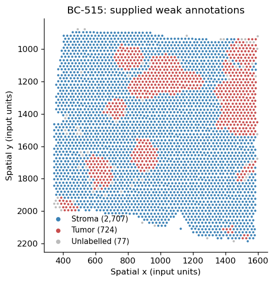

```python
# Load the original data for training.
adata = ad.read_h5ad(INPUT)
assert adata.n_obs == 3508 and adata.uns["msi"].shape == (3508, 2086)
assert adata.obsm["X_harmony"].shape[0] == adata.n_obs
assert adata.obs_names.is_unique
xy = np.asarray(adata.obsm["spatial"], dtype=np.float32)
annotation = adata.obs["annotation"].astype(str).to_numpy()
msi = adata.uns["msi"]
values = msi.data if issparse(msi) else np.asarray(msi)
assert np.isfinite(values).all() and np.min(values) >= 0
input_hash = sha256(INPUT)
display(pd.DataFrame({
    "Input": ["MSI intensities", "Auxiliary RNA representation", "Spatial coordinates", "Weak annotations", "RNA gene expression (not MSI)"],
    "Location": ["uns['msi']", "obsm['X_harmony'][:, :32]", "obsm['spatial']", "obs['annotation']", "X"],
    "Shape / count": [str(msi.shape), str(adata.obsm['X_harmony'][:, :32].shape), str(xy.shape),
             str(adata.n_obs), str(adata.shape)]}))
display(adata.obs["annotation"].value_counts().rename("spots").to_frame())
print("Input SHA256:", input_hash)
print("MSI storage:", type(msi).__name__, "| all 3,508 spots and 2,086 m/z features retained")

fig, ax = plt.subplots(figsize=(5.4, 4.8))
for label, color in [("Stroma", "#3B82B6"), ("Tumor", "#C84D4D"), ("Unlabelled", "#BBBBBB")]:
    use = annotation == label
    ax.scatter(xy[use, 0], xy[use, 1], s=7, c=color, label=f"{label} ({use.sum():,})", linewidths=0)
ax.set(title="BC-515: supplied weak annotations", xlabel="Spatial x (input units)", ylabel="Spatial y (input units)")
ax.set_aspect("equal"); ax.invert_yaxis(); ax.legend(frameon=False, markerscale=2, fontsize=9)
fig.tight_layout(); plt.show()
mz_names = np.asarray(adata.uns["mz_features"]).astype(str)
X_msi = msi
```

## Preprocessing and spatial diffusion

MSI log1p → robust scaling (10th–90th percentiles) → SVD64 → z-score. The directed Gaussian graph uses 15 nearest neighbors. Ten diffusion steps with alpha 0.9 define the smooth embedding; the model learns its residual. The clamped label field is exported for comparison and is not the network input.

```python
def reset_seed(seed=0):
    os.environ["PYTHONHASHSEED"] = str(seed)
    random.seed(seed); np.random.seed(seed); torch.manual_seed(seed)
    if torch.cuda.is_available():
        torch.cuda.manual_seed_all(seed)
    torch.backends.cudnn.deterministic = True
    torch.backends.cudnn.benchmark = False
    torch.use_deterministic_algorithms(True, warn_only=True)


def msi_embedding(matrix, n_components=64, seed=0):
    k = min(int(n_components), min(matrix.shape) - 1)
    if k < 1:
        raise ValueError("MSI matrix too small for SVD")
    if issparse(matrix):
        xlog = matrix.copy()
        xlog.data = np.log1p(xlog.data)
        embedding = TruncatedSVD(n_components=k, random_state=seed).fit_transform(xlog)
    else:
        xlog = np.log1p(np.asarray(matrix, dtype=np.float32))
        scaled = RobustScaler(quantile_range=(10, 90)).fit_transform(xlog)
        embedding = TruncatedSVD(n_components=k, random_state=seed).fit_transform(scaled)
    embedding = np.asarray(embedding, dtype=np.float32)
    return (embedding - embedding.mean(0)) / (embedding.std(0) + 1e-6)


def spatial_graph(xy, k=15):
    xy = np.asarray(xy, dtype=np.float32)
    k = min(int(k), xy.shape[0] - 1)
    distances, neighbors = NearestNeighbors(n_neighbors=k+1).fit(xy).kneighbors(xy)
    distances, neighbors = distances[:, 1:], neighbors[:, 1:]
    sigma = max(float(np.median(distances[distances > 0])), 1e-12)
    weights = np.exp(-(distances ** 2) / (2 * sigma ** 2)).astype(np.float32)
    src = np.repeat(np.arange(xy.shape[0]), k)
    return np.vstack([src, neighbors.ravel()]).astype(np.int64), weights.ravel(), sigma


def diffuse_embedding(edges, weights, embedding, n_iter=10, alpha=0.9):
    embedding = np.asarray(embedding, dtype=np.float32)
    field = embedding.copy()
    src, dst = edges
    deg = np.zeros(embedding.shape[0], dtype=np.float32)
    np.add.at(deg, src, weights)
    deg = np.maximum(deg, 1e-12)
    for _ in range(n_iter):
        messages = np.zeros_like(field)
        np.add.at(messages, src, weights[:, None] * field[dst])
        field = alpha * (messages / deg[:, None]) + (1-alpha) * embedding
    return field


def diffuse_anchors(edges, weights, labels, mask, n_iter=50, alpha=0.85):
    field = np.zeros(len(labels), dtype=np.float32)
    field[mask] = labels[mask].astype(np.float32)
    anchor = field.copy()
    src, dst = edges
    deg = np.zeros(len(labels), dtype=np.float32)
    np.add.at(deg, src, weights)
    deg = np.maximum(deg, 1e-12)
    for _ in range(n_iter):
        messages = np.zeros(len(labels), dtype=np.float32)
        np.add.at(messages, src, weights * field[dst])
        updated = alpha * (messages / deg) + (1-alpha) * anchor
        updated[mask] = anchor[mask]
        field = updated
    return field
```

## Spectral residual network

Two high-pass blocks apply graph filtering, linear projection, LayerNorm, ReLU and dropout. Initialize the RNA projection before the residual reconstruction head, preserving the random-number order in the original notebook. This notebook imports NumPy, scikit-learn, PyTorch and PyG, but does not import SIGMA.

```python
class GraphLowPass(MessagePassing):
    def __init__(self):
        super().__init__(aggr="add")

    def forward(self, x, edge_index, edge_weight=None):
        n = x.size(0)
        if edge_weight is None:
            edge_weight = torch.ones(edge_index.size(1), device=x.device, dtype=x.dtype)
        edges, weights = add_self_loops(edge_index, edge_weight, fill_value=1.0, num_nodes=n)
        row, col = edges
        # Match the library degree normalization using incoming edge counts.
        inverse = degree(col, n, dtype=x.dtype).pow(-0.5)
        inverse[torch.isinf(inverse)] = 0
        norm = inverse[row] * weights * inverse[col]
        return self.propagate(edges, x=x, norm=norm)

    def message(self, x_j, norm):
        return norm.view(-1, 1) * x_j


class SpectralHighPassBlock(nn.Module):
    def __init__(self, in_dim, out_dim, dropout=0.1):
        super().__init__()
        self.lowpass = GraphLowPass()
        self.lin = nn.Linear(in_dim, out_dim)
        self.norm = nn.LayerNorm(out_dim)
        self.dropout = nn.Dropout(dropout)

    def forward(self, x, edge_index, edge_weight=None):
        highpass = x - self.lowpass(x, edge_index, edge_weight)
        return self.dropout(F.relu(self.norm(self.lin(highpass))))


class SpectralResidualNet(nn.Module):
    def __init__(self, in_dim, hidden=128, out_dim=64, r_dim=None, z_dim=32):
        super().__init__()
        r_dim = in_dim if r_dim is None else r_dim
        self.hp1 = SpectralHighPassBlock(in_dim, hidden)
        self.hp2 = SpectralHighPassBlock(hidden, out_dim)
        # Preserve the original RNA-first initialization order.
        self.rna_head = nn.Linear(out_dim, z_dim)
        self.residual_head = nn.Linear(out_dim, r_dim)
        self.region_head = nn.Linear(out_dim, 1)

    def forward(self, x, edge_index, edge_weight=None):
        h = self.hp2(self.hp1(x, edge_index, edge_weight), edge_index, edge_weight)
        return {"r": self.residual_head(h), "z_hat": self.rna_head(h),
                "h": h, "logit": self.region_head(h).squeeze(-1)}
```

## Train for 1,000 epochs

The loss combines SmoothL1 for MSI residuals, 0.05 × weighted BCE for annotations and 0.05 × RNA reconstruction MSE. Adam uses learning rate 0.001 and weight decay 0.0001.

```python
reset_seed(SEED)
start = time.perf_counter()
embedding = msi_embedding(msi, CORE["n_components"], SEED)
edges, edge_weights, kernel_sigma = spatial_graph(xy, CORE["k"])
gaussian = diffuse_embedding(edges, edge_weights, embedding)
residual_target = embedding - gaussian
y = np.full(adata.n_obs, -1, dtype=np.int64)
y[annotation == "Tumor"] = 1
y[annotation == "Stroma"] = 0
mask = y >= 0
assert np.any(y[mask] == 1) and np.any(y[mask] == 0)
gaussian_anchor = diffuse_anchors(edges, edge_weights, y, mask)
z = np.asarray(adata.obsm["X_harmony"][:, :CORE["z_dim"]], dtype=np.float32)
z = (z - z.mean(0)) / (z.std(0) + 1e-6)
data = Data(x=torch.tensor(gaussian, dtype=torch.float32),
            edge_index=torch.tensor(edges, dtype=torch.long),
            edge_attr=torch.tensor(edge_weights, dtype=torch.float32)).to("cpu")
r_target_tensor = torch.tensor(residual_target, dtype=torch.float32)
z_tensor = torch.tensor(z, dtype=torch.float32)
anchor_indices = torch.tensor(np.where(mask)[0], dtype=torch.long)
anchor_labels = torch.tensor(y[mask], dtype=torch.float32)
reset_seed(SEED)
model = SpectralResidualNet(embedding.shape[1], hidden=128,
                           out_dim=embedding.shape[1], r_dim=embedding.shape[1],
                           z_dim=z.shape[1]).to("cpu")
optimizer = torch.optim.Adam(model.parameters(), lr=CORE["lr"], weight_decay=1e-4)
positive, negative = (y[mask] == 1).sum(), (y[mask] == 0).sum()
positive_weight = torch.tensor([negative / max(positive, 1)])
loss_history = []
for epoch in range(CORE["epochs"]):
    model.train(); optimizer.zero_grad()
    output = model(data.x, data.edge_index, data.edge_attr)
    loss_rec = F.smooth_l1_loss(output["r"], r_target_tensor)
    loss_sup = F.binary_cross_entropy_with_logits(output["logit"][anchor_indices],
                                                anchor_labels, pos_weight=positive_weight)
    loss_rna = F.mse_loss(output["z_hat"], z_tensor)
    loss = loss_rec + CORE["lambda_sup"] * loss_sup + CORE["beta_rna"] * loss_rna
    loss.backward(); optimizer.step()
    loss_history.append(float(loss.detach().cpu()))
    if epoch == 0 or (epoch + 1) % 200 == 0:
        print(f"epoch={epoch+1:4d}/{CORE['epochs']} loss={loss_history[-1]:.6f}", flush=True)

model.eval()
with torch.no_grad():
    output = model(data.x, data.edge_index, data.edge_attr)
    residual = output["r"].cpu().numpy()
    logit = output["logit"].cpu().numpy()
    p_raw = 1.0 / (1.0 + np.exp(-logit))
    probability = (p_raw - np.nanmin(p_raw)) / (np.nanmax(p_raw) - np.nanmin(p_raw) + 1e-8)
training_seconds = time.perf_counter() - start
print(f"Fresh full-data training completed in {training_seconds:.1f} s")
```

```
epoch=   1/1000 loss=0.425294
```

```
epoch= 200/1000 loss=0.201186
```

```
epoch= 400/1000 loss=0.176500
```

```
epoch= 600/1000 loss=0.165789
```

```
epoch= 800/1000 loss=0.158740
```

```
epoch=1000/1000 loss=0.155556
```

```
Fresh full-data training completed in 140.2 s
```

## Construct the interface

Threshold the normalized region score at 0.5. Boundary spots have both same-class and opposite-class neighbors among their ten nearest neighbors. Signed distance is the nearest-boundary distance, negative inside and positive outside.

```python
def boundary_and_distance(xy, probability, k_nn=10):
    coords = np.asarray(xy, dtype=float)
    field = np.asarray(probability, dtype=float)
    if not np.isfinite(field).all():
        raise ValueError("Non-finite probability")
    inside = field >= 0.5
    k_nn = min(int(k_nn), len(coords)-1)
    neighbors = NearestNeighbors(n_neighbors=k_nn+1).fit(coords).kneighbors(
        coords, return_distance=False)[:, 1:]
    same = np.any(inside[neighbors] == inside[:, None], axis=1)
    opposite = np.any(inside[neighbors] != inside[:, None], axis=1)
    boundary = same & opposite
    if not boundary.any():
        raise ValueError("No boundary detected")
    distance = NearestNeighbors(n_neighbors=1).fit(coords[boundary]).kneighbors(
        coords, return_distance=True)[0][:, 0]
    return boundary, inside, np.where(inside, -distance, distance)

xy = np.asarray(adata.obsm["spatial"], dtype=float)
boundary, inside, d_signed = boundary_and_distance(xy, probability, CORE["boundary_k"])
adata.obsm["X_sigma_msi"] = embedding
adata.obsm["X_sigma_gauss"] = gaussian
adata.obsm["X_sigma_residual"] = residual
adata.obsm["X_sigma_corrected"] = gaussian + residual
adata.obs["sigma_gaussian_anchor"] = gaussian_anchor
adata.obs["sigma_region_probability_raw"] = p_raw
adata.obs["sigma_region_probability"] = probability
adata.obs["sigma_inside"] = inside
adata.obs["sigma_boundary"] = boundary
adata.obs["sigma_d_signed"] = d_signed
```

## Region field, boundary and signed distance

The normalized region score is a within-section visualization and boundary-construction score; it is not a calibrated probability. Weak annotations were used during training.

|  | Fresh result |
| --- | --- |
| spots | 3508.000000 |
| MSI features | 2086.000000 |
| epochs | 1000.000000 |
| initial training loss | 0.425294 |
| final training loss | 0.155556 |
| inside spots | 751.000000 |
| boundary spots | 838.000000 |
| training seconds | 140.179592 |

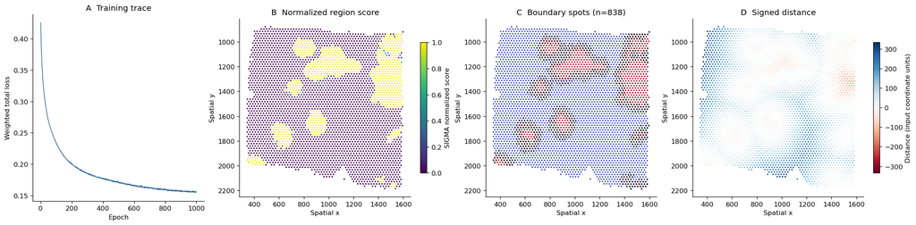

```python
probability = adata.obs["sigma_region_probability"].to_numpy()
p_raw = adata.obs["sigma_region_probability_raw"].to_numpy()
boundary = adata.obs["sigma_boundary"].to_numpy(bool)
inside = adata.obs["sigma_inside"].to_numpy(bool)
d_signed = adata.obs["sigma_d_signed"].to_numpy()
assert np.isfinite(probability).all() and np.isfinite(d_signed).all()
assert boundary.any() and inside.any() and (~inside).any()
assert len(loss_history) == CORE["epochs"]
display(pd.Series({"spots": adata.n_obs, "MSI features": msi.shape[1],
                   "epochs": len(loss_history), "initial training loss": loss_history[0],
                   "final training loss": loss_history[-1], "inside spots": int(inside.sum()),
                   "boundary spots": int(boundary.sum()), "training seconds": training_seconds},
                  name="Fresh result").to_frame())

fig, axes = plt.subplots(1, 4, figsize=(19, 4.6), layout="constrained")
axes[0].plot(np.arange(1, len(loss_history)+1), loss_history, color="#356B9C", lw=1)
axes[0].set(title="A  Training trace", xlabel="Epoch", ylabel="Weighted total loss")
image = axes[1].scatter(xy[:, 0], xy[:, 1], c=probability, s=5, vmin=0, vmax=1, linewidths=0)
axes[1].set_title("B  Normalized region score")
fig.colorbar(image, ax=axes[1], shrink=.7, label="SIGMA normalized score")
axes[2].scatter(xy[:, 0], xy[:, 1], c=inside, cmap="coolwarm", s=5, linewidths=0)
axes[2].scatter(xy[boundary, 0], xy[boundary, 1], c="#222222", s=5, linewidths=0)
axes[2].set_title(f"C  Boundary spots (n={boundary.sum():,})")
limit = np.max(np.abs(d_signed))
image = axes[3].scatter(xy[:, 0], xy[:, 1], c=d_signed, cmap="RdBu", s=5,
                        vmin=-limit, vmax=limit, linewidths=0)
axes[3].set_title("D  Signed distance")
fig.colorbar(image, ax=axes[3], shrink=.7, label="Distance (input coordinate units)")
for ax in axes[1:]:
    ax.set_aspect("equal"); ax.invert_yaxis()
    ax.set(xlabel="Spatial x", ylabel="Spatial y")
fig.savefig(OUT / "core_results.png", bbox_inches="tight")
fig.savefig(OUT / "core_results.pdf", bbox_inches="tight")
plt.show()
```

## Boundary-associated decay features

For each of the 2,000 most variable MSI features, fit

`log1p(I - min(I)) = intercept + slope × abs(d_signed)`

with Huber regression. A negative slope gives `lambda = -1 / slope`. Retain features with at least 300 valid spots, R² ≥ 0.05 and near/far mean intensity ratio ≥ 1.05. Near and far use the 20th and 80th absolute-distance percentiles. Remove the upper 1% of retained lambda values, then rank by R² and enrichment. This is the original distance-decay ranking.

```python
def column_get(X, j):
    """
    Extract the j-th feature vector from dense or sparse matrix.

    Parameters
    ----------
    X : array-like or sparse matrix
        MSI feature matrix.
    j : int
        Feature index.

    Returns
    -------
    y : ndarray, shape (n_spots,)
        Feature intensity vector.
    """
    if issparse(X):
        return X[:, j].toarray().ravel()
    return np.asarray(X[:, j]).ravel()

def fit_lambda_exponential(d_abs, y, min_valid=300, eps=1e-08):
    """
    Robustly fit an exponential decay model:

        log1p(y_shifted) ≈ intercept + slope * distance

    where:
        slope < 0 indicates boundary-high and distance-decay pattern
        lambda = -1 / slope

    Parameters
    ----------
    d_abs : array-like, shape (n_spots,)
        Absolute distance to the inferred interface.
    y : array-like, shape (n_spots,)
        MSI feature intensity.
    min_valid : int
        Minimum number of valid observations required.
    eps : float
        Minimum signal threshold.

    Returns
    -------
    lam : float
        Interface influence range. Larger values indicate broader spatial influence.
    r2 : float
        R-squared of the fitted model on log1p intensity.
    slope : float
        Fitted slope in log-intensity versus distance.
    intercept : float
        Fitted intercept.
    n_valid : int
        Number of valid observations.
    """
    dd = np.asarray(d_abs, dtype=float)
    yy = np.asarray(y, dtype=float)
    mask = np.isfinite(dd) & np.isfinite(yy)
    dd = dd[mask]
    yy = yy[mask]
    n_valid = dd.size
    if n_valid < min_valid:
        return (np.nan, np.nan, np.nan, np.nan, n_valid)
    y_min = np.nanmin(yy)
    yy_shifted = yy - y_min
    if np.nanpercentile(yy_shifted, 99) < eps:
        return (np.nan, np.nan, np.nan, np.nan, n_valid)
    t = np.log1p(yy_shifted)
    X = dd.reshape(-1, 1)
    model = HuberRegressor().fit(X, t)
    pred = model.predict(X)
    r2 = r2_score(t, pred)
    slope = float(model.coef_[0])
    intercept = float(model.intercept_)
    if slope >= 0:
        lam = np.nan
    else:
        lam = -1.0 / slope
    return (lam, r2, slope, intercept, n_valid)

def boundary_enrichment_score(d_abs, y, near_quantile=0.2, far_quantile=0.8, eps=1e-08):
    """
    Estimate whether a feature is enriched near the interface.

    Boundary enrichment is defined as:

        mean intensity near interface / mean intensity far from interface

    Parameters
    ----------
    d_abs : array-like, shape (n_spots,)
        Absolute distance to the inferred interface.
    y : array-like, shape (n_spots,)
        MSI feature intensity.
    near_quantile : float
        Quantile threshold for near-interface spots.
    far_quantile : float
        Quantile threshold for far-interface spots.
    eps : float
        Small constant to avoid division by zero.

    Returns
    -------
    enrich_ratio : float
        Near-interface mean divided by far-interface mean.
    near_mean : float
        Mean intensity near the interface.
    far_mean : float
        Mean intensity far from the interface.
    """
    dd = np.asarray(d_abs, dtype=float)
    yy = np.asarray(y, dtype=float)
    mask = np.isfinite(dd) & np.isfinite(yy)
    dd = dd[mask]
    yy = yy[mask]
    if dd.size == 0:
        return (np.nan, np.nan, np.nan)
    near_thr = np.quantile(dd, near_quantile)
    far_thr = np.quantile(dd, far_quantile)
    near_mask = dd <= near_thr
    far_mask = dd >= far_thr
    if near_mask.sum() == 0 or far_mask.sum() == 0:
        return (np.nan, np.nan, np.nan)
    near_mean = float(np.nanmean(yy[near_mask]))
    far_mean = float(np.nanmean(yy[far_mask]))
    enrich_ratio = (near_mean + eps) / (far_mean + eps)
    return (enrich_ratio, near_mean, far_mean)

def rank_mz_by_lambda(X, mz_names, d_abs, var_top=3000, max_mz=None, random_state=0, min_valid=300, min_r2=0.05, min_enrich_ratio=1.05, max_lambda_quantile=0.99):
    """
    Scan MSI features and identify boundary-associated decay patterns.

    This function fits an exponential decay model for each feature:

        log1p(intensity_shifted) ≈ intercept - distance / lambda

    Features are retained if they show:
        1. negative slope
        2. finite lambda
        3. sufficient model fit
        4. near-interface enrichment

    Parameters
    ----------
    X : array-like or sparse matrix, shape (n_spots, n_features)
        MSI feature matrix.
    mz_names : ndarray, shape (n_features,)
        MSI feature names.
    d_abs : array-like, shape (n_spots,)
        Absolute distance to interface.
    var_top : int or None
        Select top variable features before fitting. If None, scan all features.
    max_mz : int or None
        Randomly subsample features after variance filtering.
    random_state : int
        Random seed for subsampling.
    min_valid : int
        Minimum number of valid observations per feature.
    min_r2 : float
        Minimum R-squared threshold.
    min_enrich_ratio : float
        Minimum near-interface enrichment ratio.
    max_lambda_quantile : float
        Remove extremely large lambda values above this quantile.

    Returns
    -------
    df : pandas.DataFrame
        Ranked feature table.
    """
    n, p = X.shape
    cols = np.arange(p)
    if var_top is not None and var_top < p:
        if issparse(X):
            mean = np.asarray(X.mean(axis=0)).ravel()
            mean2 = np.asarray(X.power(2).mean(axis=0)).ravel()
            var = mean2 - mean ** 2
        else:
            var = np.var(np.asarray(X), axis=0)
        cols = np.argsort(var)[::-1][:var_top]
    if max_mz is not None and max_mz < len(cols):
        rng = np.random.default_rng(random_state)
        cols = rng.choice(cols, size=max_mz, replace=False)
    rows = []
    for j in cols:
        y = column_get(X, j)
        lam, r2, slope, intercept, n_valid = fit_lambda_exponential(d_abs=d_abs, y=y, min_valid=min_valid)
        enrich_ratio, near_mean, far_mean = boundary_enrichment_score(d_abs=d_abs, y=y, near_quantile=0.2, far_quantile=0.8)
        if not np.isfinite(lam):
            continue
        if not np.isfinite(r2):
            continue
        if not np.isfinite(enrich_ratio):
            continue
        if slope >= 0:
            continue
        if r2 < min_r2:
            continue
        if enrich_ratio < min_enrich_ratio:
            continue
        rows.append({'mz': mz_names[j], 'j': int(j), 'lambda': float(lam), 'r2_logI': float(r2), 'slope': float(slope), 'intercept': float(intercept), 'n_valid': int(n_valid), 'boundary_enrichment_ratio': float(enrich_ratio), 'near_interface_mean': float(near_mean), 'far_interface_mean': float(far_mean)})
    df = pd.DataFrame(rows)
    if df.empty:
        return df
    if max_lambda_quantile is not None and 0 < max_lambda_quantile < 1:
        lam_thr = df['lambda'].quantile(max_lambda_quantile)
        df = df[df['lambda'] <= lam_thr].copy()
    df = df.sort_values(['r2_logI', 'boundary_enrichment_ratio'], ascending=[False, False]).reset_index(drop=True)
    return df
```

```python
ranking = rank_mz_by_lambda(
    X=msi, mz_names=mz_names, d_abs=np.abs(d_signed), var_top=2000,
    max_mz=None, random_state=SEED, min_valid=300, min_r2=0.05,
    min_enrich_ratio=1.05, max_lambda_quantile=0.99)
```

```python
assert not ranking.empty, "No features passed the original distance-decay filters."
assert (ranking["slope"] < 0).all()
assert (ranking["r2_logI"] >= 0.05).all()
assert (ranking["boundary_enrichment_ratio"] >= 1.05).all()
print(f"Retained {len(ranking)} boundary-decay features from 2,000 variance-selected candidates.")
display(ranking[["mz", "j", "lambda", "r2_logI", "boundary_enrichment_ratio"]].head(10))
ranking.to_csv(OUT / "lambda_ranking.csv", index=False)
```

```
Retained 312 boundary-decay features from 2,000 variance-selected candidates.
```

|  | mz | j | lambda | r2_logI | boundary_enrichment_ratio |
| --- | --- | --- | --- | --- | --- |
| 0 | 817.5345203639481 | 320 | 226.598438 | 0.270282 | 2.411772 |
| 1 | 818.540767079965 | 134 | 195.740959 | 0.269265 | 2.569555 |
| 2 | 887.5614622133272 | 75 | 173.717959 | 0.268716 | 3.657773 |
| 3 | 816.5355232640409 | 127 | 235.808809 | 0.265604 | 2.229208 |
| 4 | 819.5397641798722 | 267 | 190.766553 | 0.256956 | 2.912609 |
| 5 | 768.5372649253893 | 91 | 209.982640 | 0.251133 | 2.620186 |
| 6 | 766.534920955909 | 60 | 198.043845 | 0.251068 | 2.701397 |
| 7 | 822.5686537904764 | 158 | 195.255653 | 0.249306 | 2.805875 |
| 8 | 820.5590602048865 | 74 | 185.205432 | 0.245908 | 2.800793 |
| 9 | 885.5489687812933 | 25 | 196.482274 | 0.242049 | 2.472738 |

## Directional variation of influence range

Eight angular sectors are defined around the tissue center. Anisotropy is the population standard deviation of valid sector lambda values divided by their mean, with at least three valid sectors.

```python
def column_get(X, j):
    """
    Extract the j-th feature vector from dense or sparse matrix.

    Parameters
    ----------
    X : array-like or sparse matrix
        MSI feature matrix.
    j : int
        Feature index.

    Returns
    -------
    y : ndarray, shape (n_spots,)
        Feature intensity vector.
    """
    if issparse(X):
        return X[:, j].toarray().ravel()
    return np.asarray(X[:, j]).ravel()

def get_sector8(xy):
    center = np.nanmean(xy, axis=0)
    v = xy - center
    angle = np.arctan2(v[:, 1], v[:, 0])
    angle = (angle + 2 * np.pi) % (2 * np.pi)
    sector = np.floor(angle / (2 * np.pi / 8)).astype(int)
    return (sector, center)

def fit_lambda_simple(d_abs, y, min_valid=150):
    mask = np.isfinite(d_abs) & np.isfinite(y)
    d_abs = d_abs[mask]
    y = y[mask]
    if len(y) < min_valid:
        return (np.nan, np.nan, np.nan)
    y = y - np.nanmin(y)
    if np.nanpercentile(y, 99) <= 1e-08:
        return (np.nan, np.nan, np.nan)
    t = np.log1p(y)
    X = d_abs.reshape(-1, 1)
    model = HuberRegressor().fit(X, t)
    pred = model.predict(X)
    r2 = r2_score(t, pred)
    slope = float(model.coef_[0])
    if slope >= 0:
        return (np.nan, r2, slope)
    lam = -1.0 / slope
    return (lam, r2, slope)

def lambda_by_sector(mz_name, df_lambda, X_msi, d_signed, sector8, min_pts=150):
    row = df_lambda[df_lambda['mz'].astype(str) == str(mz_name)].iloc[0]
    j = int(row['j'])
    y = column_get(X_msi, j)
    rows = []
    for s in range(8):
        mask = sector8 == s
        lam, r2, slope = fit_lambda_simple(np.abs(d_signed[mask]), y[mask], min_valid=min_pts)
        rows.append({'sector': s, 'lambda': lam, 'r2_logI': r2, 'slope': slope, 'n': int(mask.sum())})
    return pd.DataFrame(rows)

def anisotropy_cv(mz_name, df_lambda, X_msi, d_signed, sector8):
    df_sec = lambda_by_sector(mz_name, df_lambda, X_msi, d_signed, sector8, min_pts=150)
    lam = df_sec['lambda'].to_numpy()
    lam = lam[np.isfinite(lam)]
    if len(lam) < 3:
        return np.nan
    return np.std(lam) / (np.mean(lam) + 1e-08)
```

```python
sector8, tissue_center = get_sector8(xy)
adata.obs["sector8"] = sector8
# The original analysis clusters the first 300 retained decay features.
top = ranking.head(300).copy()
top["anisotropy_cv8"] = [
    anisotropy_cv(mz, ranking, msi, d_signed, sector8)
    for mz in top["mz"].astype(str)
]
top = top.sort_values(["r2_logI", "anisotropy_cv8"], ascending=[False, False])
top.to_csv(OUT / "top300_lambda_anisotropy.csv", index=False)
display(top[["mz", "lambda", "r2_logI", "anisotropy_cv8"]].head(10))
```

|  | mz | lambda | r2_logI | anisotropy_cv8 |
| --- | --- | --- | --- | --- |
| 0 | 817.5345203639481 | 226.598438 | 0.270282 | 0.423022 |
| 1 | 818.540767079965 | 195.740959 | 0.269265 | 0.749549 |
| 2 | 887.5614622133272 | 173.717959 | 0.268716 | 0.928248 |
| 3 | 816.5355232640409 | 235.808809 | 0.265604 | 0.423050 |
| 4 | 819.5397641798722 | 190.766553 | 0.256956 | 0.720046 |
| 5 | 768.5372649253893 | 209.982640 | 0.251133 | 0.779187 |
| 6 | 766.534920955909 | 198.043845 | 0.251068 | 0.819968 |
| 7 | 822.5686537904764 | 195.255653 | 0.249306 | 1.257684 |
| 8 | 820.5590602048865 | 185.205432 | 0.245908 | 1.127496 |
| 9 | 885.5489687812933 | 196.482274 | 0.242049 | 0.533185 |

## Signed-distance metabolic programs

Calculate eight-sector lambda anisotropy for the first 300 retained features, requiring 150 spots per sector. Sort by R² and anisotropy. Average each raw-intensity feature in 40 equal-width signed-distance bins spanning the 2nd–98th percentiles. Require five spots per bin and at least 80% defined bins; interpolate gaps and standardize each profile. Ward clustering divides the profiles into four programs.

Program curves show mean ± SD across member feature profiles. A spatial module score is the mean of each member feature's raw-intensity z-score, without an additional normalization of the final score.

```python
d = d_signed
bins = np.linspace(np.percentile(d, 2), np.percentile(d, 98), 41)

def make_binned_profile(y, d_signed, bins, min_pts=5):
    bin_id = np.digitize(d_signed, bins) - 1
    profile = []
    for b in range(len(bins) - 1):
        use = bin_id == b
        profile.append(np.nanmean(y[use]) if use.sum() >= min_pts else np.nan)
    return np.asarray(profile, dtype=float)

profiles, meta_rows = [], []
for _, row in top.iterrows():
    values = column_get(msi, int(row["j"]))
    profile = make_binned_profile(values, d, bins, min_pts=5)
    series = pd.Series(profile)
    if series.notna().sum() < 0.80 * len(series):
        continue
    profile = series.interpolate(limit_direction="both").to_numpy()
    profile = (profile - profile.mean()) / (profile.std() + 1e-6)
    profiles.append(profile)
    meta_rows.append(row)
profile_mat = np.vstack(profiles)
meta_df = pd.DataFrame(meta_rows).reset_index(drop=True)
meta_df["cluster"] = AgglomerativeClustering(n_clusters=4, linkage="ward").fit_predict(profile_mat)
module_scores = {}
for cluster in sorted(meta_df["cluster"].unique()):
    indices = meta_df.loc[meta_df["cluster"] == cluster, "j"].astype(int).to_numpy()
    values = msi[:, indices].toarray().astype(float) if issparse(msi) else msi[:, indices].astype(float)
    feature_z = (values - values.mean(axis=0)) / (values.std(axis=0) + 1e-6)
    module_scores[int(cluster)] = feature_z.mean(axis=1)
```

```
Profile matrix: (300, 40)
```

| cluster | Features |
| --- | --- |
| 0 | 30 |
| 1 | 97 |
| 2 | 161 |
| 3 | 12 |

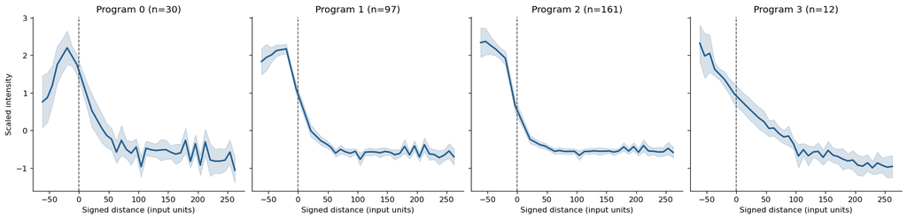

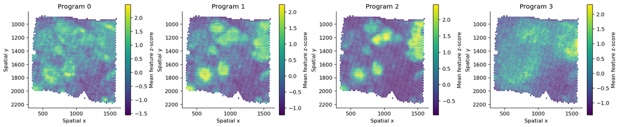

```python
assert profile_mat.shape[1] == 40
print("Profile matrix:", profile_mat.shape)
display(meta_df.groupby("cluster").size().rename("Features").to_frame())
meta_df.to_csv(OUT / "program_assignments.csv", index=False)
pd.DataFrame(module_scores, index=adata.obs_names).rename_axis("obs_id").to_csv(OUT / "program_scores.csv")
centers = 0.5 * (bins[:-1] + bins[1:])
clusters = sorted(meta_df["cluster"].unique())
fig, axes = plt.subplots(1, 4, figsize=(16, 3.8), sharey=True, layout="constrained")
for ax, cluster in zip(axes, clusters):
    members = meta_df["cluster"].to_numpy() == cluster
    block = profile_mat[members]
    mean, sd = block.mean(axis=0), block.std(axis=0)
    ax.plot(centers, mean, color="#245E8D", linewidth=2)
    ax.fill_between(centers, mean - sd, mean + sd, color="#245E8D", alpha=0.18)
    ax.axvline(0, color="#444444", linestyle="--", linewidth=1)
    ax.set(title=f"Program {cluster} (n={members.sum()})", xlabel="Signed distance (input units)")
axes[0].set_ylabel("Scaled intensity")
fig.savefig(OUT / "program_profiles.png", bbox_inches="tight")
fig.savefig(OUT / "program_profiles.pdf", bbox_inches="tight")
plt.show()

fig, axes = plt.subplots(1, 4, figsize=(16, 4.5), layout="constrained")
for ax, cluster in zip(axes, clusters):
    picture = ax.scatter(xy[:, 0], xy[:, 1], c=module_scores[int(cluster)], s=6, linewidths=0)
    ax.set_aspect("equal"); ax.invert_yaxis()
    ax.set(title=f"Program {cluster}", xlabel="Spatial x", ylabel="Spatial y")
    fig.colorbar(picture, ax=ax, shrink=0.65, label="Mean feature z-score")
fig.savefig(OUT / "program_maps.png", bbox_inches="tight")
fig.savefig(OUT / "program_maps.pdf", bbox_inches="tight")
plt.show()
```

## One representative feature per program

Within each inferred program, remove lambda values above that program's 90th percentile and choose the feature with highest R², breaking ties by enrichment. This follows the original representative-selection step; representatives are not a global top-four list.

The lower panels use absolute distance, 30 quantile bins and mean ± SEM of min–max normalized intensities. Repeated distance values can reduce the number of distinct bins. Lambda and R² are fitted to raw intensities after the original log1p shift. The dashed display curve keeps that fitted slope and adjusts the intercept for normalized intensities, as in the original plotting code. It is not a new fit to the binned means.

```python
import numpy as np
import pandas as pd
lambda_col = 'lambda' if 'lambda' in meta_df.columns else 'lam'
df_rep = meta_df.copy()
df_rep = df_rep.replace([np.inf, -np.inf], np.nan)
required_cols = ['cluster', 'mz', 'j', 'r2_logI']
missing = [c for c in required_cols if c not in df_rep.columns]
if missing:
    raise KeyError(f'Missing required columns in meta_df: {missing}')
rank_cols = ['r2_logI']
ascending = [False]
if 'boundary_enrichment_ratio' in df_rep.columns:
    rank_cols.append('boundary_enrichment_ratio')
    ascending.append(False)
if lambda_col in df_rep.columns:
    df_rep[lambda_col] = pd.to_numeric(df_rep[lambda_col], errors='coerce')
df_rep = df_rep.dropna(subset=['cluster', 'mz', 'j', 'r2_logI'])
rep_rows = []
for c in sorted(df_rep['cluster'].unique()):
    sub = df_rep[df_rep['cluster'] == c].copy()
    if sub.empty:
        continue
    if lambda_col in sub.columns:
        lam_cut = np.nanpercentile(sub[lambda_col], 90)
        sub2 = sub[sub[lambda_col] <= lam_cut].copy()
        if len(sub2) >= 1:
            sub = sub2
    sub = sub.sort_values(rank_cols, ascending=ascending)
    rep_rows.append(sub.iloc[0])
df_cluster_rep = pd.DataFrame(rep_rows).reset_index(drop=True)
display_cols = ['cluster', 'mz', 'j', 'r2_logI']
for col in ['boundary_enrichment_ratio', lambda_col, 'anisotropy_cv8']:
    if col in df_cluster_rep.columns:
        display_cols.append(col)
display(df_cluster_rep[display_cols])
df_cluster_rep.to_csv(OUT / "program_representatives.csv", index=False)
```

|  | cluster | mz | j | r2_logI | boundary_enrichment_ratio | lambda | anisotropy_cv8 |
| --- | --- | --- | --- | --- | --- | --- | --- |
| 0 | 0 | 817.5345203639481 | 320 | 0.270282 | 2.411772 | 226.598438 | 0.423022 |
| 1 | 1 | 818.540767079965 | 134 | 0.269265 | 2.569555 | 195.740959 | 0.749549 |
| 2 | 2 | 887.5614622133272 | 75 | 0.268716 | 3.657773 | 173.717959 | 0.928248 |
| 3 | 3 | 328.05783972026 | 438 | 0.216272 | 2.647179 | 309.712223 | 0.407631 |

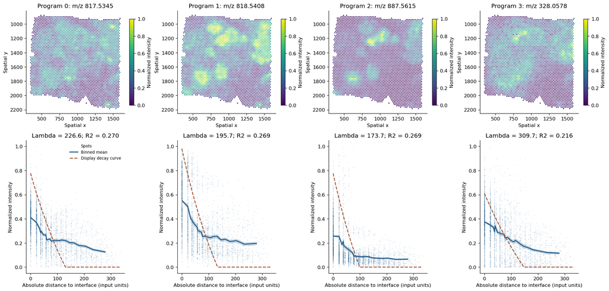

```python
# Each column shows the representative chosen within one inferred program.
# Lambda and R2 come from the raw-intensity fit. The dashed curve follows
# the original normalized-display convention: fixed slope, adjusted intercept.
fig, axes = plt.subplots(2, 4, figsize=(17, 8.3), layout="constrained")
profile_rows = []
for column, (_, row) in enumerate(df_cluster_rep.iterrows()):
    intensity = column_get(msi, int(row["j"])).astype(float)
    distance = np.abs(d_signed)
    valid = np.isfinite(distance) & np.isfinite(intensity)
    dd, raw = distance[valid], intensity[valid]
    normalized = (raw - np.nanmin(raw)) / (np.nanmax(raw) - np.nanmin(raw) + 1e-8)
    color_values = (intensity - np.nanmin(intensity)) / (np.nanmax(intensity) - np.nanmin(intensity) + 1e-8)
    ax = axes[0, column]
    picture = ax.scatter(xy[:, 0], xy[:, 1], c=color_values, s=5, vmin=0, vmax=1, linewidths=0)
    ax.set_aspect("equal"); ax.invert_yaxis()
    ax.set(title=f"Program {int(row['cluster'])}: m/z {float(row['mz']):.4f}", xlabel="Spatial x", ylabel="Spatial y")
    fig.colorbar(picture, ax=ax, shrink=0.65, label="Normalized intensity")

    edges = np.unique(np.quantile(dd, np.linspace(0, 1, 31)))
    ids = np.digitize(dd, edges[1:-1], right=True)
    xb, mean, sem = [], [], []
    for b in range(len(edges) - 1):
        use = ids == b
        if use.any():
            xb.append(np.nanmean(dd[use]))
            mean.append(np.nanmean(normalized[use]))
            sem.append(np.nanstd(normalized[use]) / np.sqrt(use.sum()))
            profile_rows.append({"cluster": int(row["cluster"]), "mz": str(row["mz"]),
                                 "bin": b, "distance_mean": xb[-1], "mean_normalized_intensity": mean[-1],
                                 "sem": sem[-1], "n_spots": int(use.sum())})
    xb, mean, sem = np.asarray(xb), np.asarray(mean), np.asarray(sem)
    shift = np.nanmin(normalized)
    transformed = np.log1p(np.clip(normalized - shift, 0, None))
    display_intercept = np.nanmean(transformed - row["slope"] * dd)
    grid = np.linspace(0, dd.max(), 300)
    fitted = np.clip(np.expm1(display_intercept + row["slope"] * grid) + shift, 0, 1)
    ax = axes[1, column]
    ax.scatter(dd, normalized, s=4, alpha=0.10, linewidths=0, color="#245E8D", label="Spots")
    ax.plot(xb, mean, linewidth=2, color="#245E8D", label="Binned mean")
    ax.fill_between(xb, mean - sem, mean + sem, color="#245E8D", alpha=0.2)
    ax.plot(grid, fitted, linestyle="--", linewidth=1.7, color="#A55232", label="Display decay curve")
    ax.set(title=f"Lambda = {row['lambda']:.1f}; R2 = {row['r2_logI']:.3f}",
           xlabel="Absolute distance to interface (input units)", ylabel="Normalized intensity")
    if column == 0:
        ax.legend(frameon=False, fontsize=8)
fig.savefig(OUT / "representative_metabolites.png", bbox_inches="tight")
fig.savefig(OUT / "representative_metabolites.pdf", bbox_inches="tight")
plt.show()
pd.DataFrame(profile_rows).to_csv(OUT / "representative_distance_profiles.csv", index=False)
```

## Export numerical results

Save the input checksum, protocol, software versions, training history, complete lambda ranking, program assignments, representatives and spatial outputs. Figures are exported as PNG and PDF.

```python
source_dir = ROOT / "vendor/SIGMA/src/sigma_spatial"
source_hashes = {name: sha256(source_dir / name) for name in [
    "__init__.py", "model.py", "graph.py", "pipeline.py", "preprocessing.py",
    "boundary.py", "lambda_profile.py", "programs.py"]}
summary = {
    "implementation": IMPLEMENTATION, "protocol": PROTOCOL, "input_sha256": input_hash,
    "spots": int(adata.n_obs), "msi_features": int(msi.shape[1]),
    "core": CORE, "seed": SEED, "device": "cpu", "threads": 1,
    "initial_loss": float(loss_history[0]), "final_loss": float(loss_history[-1]),
    "inside_spots": int(inside.sum()), "boundary_spots": int(boundary.sum()),
    "retained_lambda_features": int(len(ranking)), "clustered_features": int(len(meta_df)),
    "program_sizes": {str(k): int(v) for k, v in meta_df.groupby("cluster").size().items()},
    "representatives": df_cluster_rep[["cluster", "mz", "j", "lambda", "r2_logI", "boundary_enrichment_ratio"]].to_dict("records"),
    "training_seconds": training_seconds, "versions": versions,
    "library_compatibility_version": "0.3.1+bc515.original", "vendor_source_sha256": source_hashes,
    "reference_scope": "Original BC-515 protocol rerun; saved historical outputs are reported separately."
}
(OUT / "summary.json").write_text(json.dumps(summary, indent=2), encoding="utf-8")
np.savez_compressed(OUT / "outputs.npz", obs_names=adata.obs_names.to_numpy(dtype=str),
                    xy=xy, embedding=embedding, gaussian=gaussian, residual=residual,
                    corrected=gaussian + residual, gaussian_anchor=gaussian_anchor,
                    probability=probability, p_raw=p_raw, inside=inside, boundary=boundary,
                    d_signed=d_signed, loss_history=np.asarray(loss_history),
                    profile_matrix=profile_mat, program_feature_index=meta_df["j"].to_numpy(int),
                    program_labels=meta_df["cluster"].to_numpy(int),
                    module_scores=np.column_stack([module_scores[c] for c in sorted(module_scores)]),
                    input_sha256=np.array(input_hash), protocol=np.array(PROTOCOL))
pd.DataFrame({"obs_id": adata.obs_names, "score": probability, "inside": inside,
              "boundary": boundary, "d_signed": d_signed}).to_csv(OUT / "spatial_results.csv", index=False)
pd.DataFrame({"epoch": np.arange(1, len(loss_history) + 1), "loss": loss_history}).to_csv(OUT / "training_loss.csv", index=False)
print("Saved numerical outputs, ranking, programs and figures to:", OUT.relative_to(ROOT))
```

```
Saved numerical outputs, ranking, programs and figures to: results/sigma_from_scratch
```

## Comparison with the original saved run

These historical values were read from the original notebook. They are not used for fitting, selection or tuning. A fresh execution may differ numerically because of the runtime; the comparison makes those differences visible.

```python
# Historical numbers are reference observations, not targets used during training.
historical = {"Inside spots": 752, "Boundary spots": 834, "Retained decay features": 310,
              "Initial loss (rounded)": 0.4260, "Final loss (rounded)": 0.1564}
current = {"Inside spots": int(inside.sum()), "Boundary spots": int(boundary.sum()),
           "Retained decay features": len(ranking), "Initial loss (rounded)": round(loss_history[0], 4),
           "Final loss (rounded)": round(loss_history[-1], 4)}
comparison = pd.DataFrame({"Original saved notebook": historical, "This execution": current})
display(comparison)
comparison.to_csv(OUT / "historical_comparison.csv", index_label="measure")
print("Historical numbers are descriptive. CPU, library versions and numerical rounding can change a new training run.")
```

|  | Original saved notebook | This execution |
| --- | --- | --- |
| Inside spots | 752.0000 | 751.0000 |
| Boundary spots | 834.0000 | 838.0000 |
| Retained decay features | 310.0000 | 312.0000 |
| Initial loss (rounded) | 0.4260 | 0.4253 |
| Final loss (rounded) | 0.1564 | 0.1556 |

```
Historical numbers are descriptive. CPU, library versions and numerical rounding can change a new training run.
```

## Compare the independently executed implementations

Run the library notebook first. This cell compares the trained arrays, complete lambda ranking, programs and module scores. Tolerances are rtol=1e-7 and atol=1e-8.

```python
other_path = HERE / "results/sigma_library/outputs.npz"
if not other_path.exists():
    print("Run 02_SIGMA_library.ipynb to create the independent comparison outputs.")
else:
    with np.load(other_path, allow_pickle=False) as reference, np.load(OUT / "outputs.npz", allow_pickle=False) as current:
        assert str(reference["input_sha256"]) == str(current["input_sha256"])
        assert str(reference["protocol"]) == str(current["protocol"])
        assert np.array_equal(reference["obs_names"], current["obs_names"])
        checks = []
        for key in ["xy", "embedding", "gaussian", "residual", "corrected", "gaussian_anchor",
                    "probability", "p_raw", "inside", "boundary", "d_signed", "loss_history",
                    "profile_matrix", "program_feature_index", "program_labels", "module_scores"]:
            a, b = reference[key], current[key]
            same_shape = a.shape == b.shape
            difference = float(np.max(np.abs(a.astype(float) - b.astype(float)))) if same_shape and a.size else float("inf")
            match = same_shape and np.allclose(a, b, rtol=1e-7, atol=1e-8, equal_nan=True)
            checks.append({"output": key, "max_abs_difference": difference, "matches": bool(match)})
    a = pd.read_csv(HERE / "results/sigma_library/lambda_ranking.csv")
    b = pd.read_csv(OUT / "lambda_ranking.csv")
    assert np.array_equal(a["j"], b["j"]), "Feature ranking differs between implementations."
    for key in ["lambda", "r2_logI", "slope", "intercept", "boundary_enrichment_ratio"]:
        difference = float(np.max(np.abs(a[key].to_numpy() - b[key].to_numpy())))
        checks.append({"output": "ranking_" + key, "max_abs_difference": difference,
                       "matches": bool(np.allclose(a[key], b[key], rtol=1e-7, atol=1e-8))})
    table = pd.DataFrame(checks)
    display(table)
    table.to_csv(OUT / "library_scratch_parity.csv", index=False)
    assert table["matches"].all(), "Inspect the comparison table before interpreting these outputs."
    print("Library and independent from-scratch results agree within the stated numerical tolerance.")
```

|  | output | max_abs_difference | matches |
| --- | --- | --- | --- |
| 0 | xy | 0.0 | True |
| 1 | embedding | 0.0 | True |
| 2 | gaussian | 0.0 | True |
| 3 | residual | 0.0 | True |
| 4 | corrected | 0.0 | True |
| 5 | gaussian_anchor | 0.0 | True |
| 6 | probability | 0.0 | True |
| 7 | p_raw | 0.0 | True |
| 8 | inside | 0.0 | True |
| 9 | boundary | 0.0 | True |
| 10 | d_signed | 0.0 | True |
| 11 | loss_history | 0.0 | True |
| 12 | profile_matrix | 0.0 | True |
| 13 | program_feature_index | 0.0 | True |
| 14 | program_labels | 0.0 | True |
| 15 | module_scores | 0.0 | True |
| 16 | ranking_lambda | 0.0 | True |
| 17 | ranking_r2_logI | 0.0 | True |
| 18 | ranking_slope | 0.0 | True |
| 19 | ranking_intercept | 0.0 | True |
| 20 | ranking_boundary_enrichment_ratio | 0.0 | True |

```
Library and independent from-scratch results agree within the stated numerical tolerance.
```

## Source and license

The original algorithm comes from `HBC_515/HBC_515_SIGMA.ipynb`. The SIGMA source is distributed under its included MIT license. Functions in this notebook implement the original workflow directly; shared method-library code is not imported.